# Homework 3

Chan Pok Wah

Before proceeding to solve the problems, make sure the `tidyverse` collection is installed in your computer.

Note that some of the code blocks in this assignment contain the expression `eval = FALSE`. This tells R Markdown to display the code contained in the block, but not to evaluate it. Remove it if you want to turn off this behavior.

### Problem 1: Plotting summary statistics with histograms

The following code generates three random vectors and then produce their histograms, respectively:

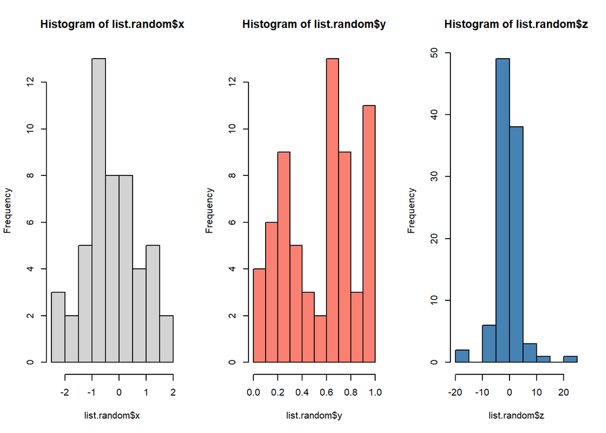

```r
# sets seed to make sure everyone's random vectors are generated the same
set.seed(201611)
list.random <- list(x = rnorm(50), y = runif(65), z = rt(100, df = 1.5))

# here's a figure showing histograms of the data
par(mfrow = c(1,3))
hist(list.random$x, col = 'lightgrey')
hist(list.random$y, col = 'salmon')
hist(list.random$z, col = 'steelblue')
```

##### (a) Denoting the means of the three vectors in the respective histograms with vertical lines.

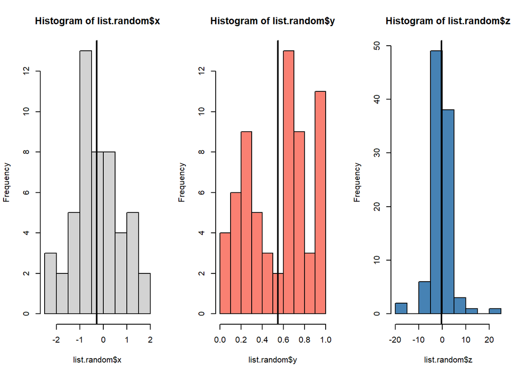

```r
# here's a figure showing histograms of the data
par(mfrow = c(1,3))

# edit here
hist(list.random$x, col = 'lightgrey')
abline(v=mean(list.random$x), col="black", lwd=2)
hist(list.random$y, col = 'salmon')
abline(v=mean(list.random$y), col="black", lwd=2)
hist(list.random$z, col = 'steelblue')
abline(v=mean(list.random$z), col="black", lwd=2)
```

##### (b) Adding density curves to approximate the three histograms.

*Tip: use a probability scale for histograms to allow the density curve to be added.*

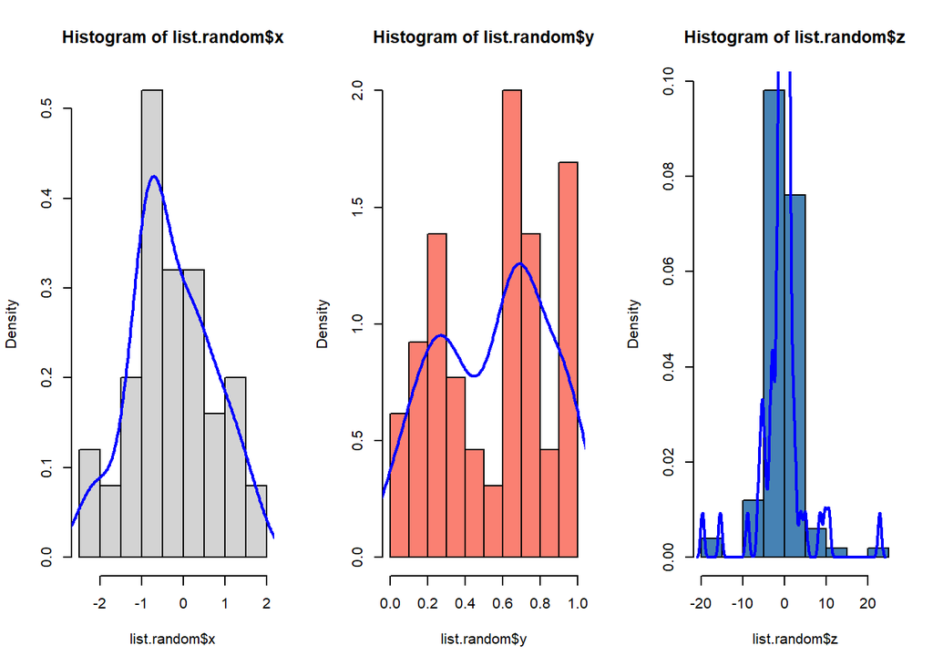

```r
# here's a figure showing histograms of the data
par(mfrow = c(1,3))
# edit here
hist(list.random$x, prob=TRUE, col="lightgrey")# prob=TRUE for probabilities not counts
lines(density(list.random$x), col="blue", lwd=2) # add a density estimate with defaults
hist(list.random$y, prob=TRUE, col="salmon")# prob=TRUE for probabilities not counts
lines(density(list.random$y), col="blue", lwd=2) # add a density estimate with defaults
hist(list.random$z, prob=TRUE, col="steelblue")# prob=TRUE for probabilities not counts
lines(density(list.random$z), col="blue", lwd=2) # add a density estimate with defaults
```

## Problem 2: Plotting financial time series for stock prices

`weeklyprice.csv` contains time series data for stock prices for three large Internet companies (Facebook, Google, and Amazon) from Oct. 30, 2012 to Oct. 30, 2017. Load the dataset to create a tibble named `weekly` using `read_csv()` from the `readr` package.

```r
weekly <- read_csv("https://drive.google.com/uc?export=download&id=1uAYO3mJYsRPAPXn-ZE5llEYebnZhcdqJ", col_names = TRUE, col_types = cols())
weekly %>% print(width = Inf)
```

```
## # A tibble: 3 x 263
##   company `2012-10-29` `2012-11-05` `2012-11-12` `2012-11-19` `2012-11-26`
##   <chr>          <dbl>        <dbl>        <dbl>        <dbl>        <dbl>
## 1 FB              21.2         19.2         23.6          24           28
## 2 GOOG           342.         329.         321.          332.         347.
## 3 AMZN           232.         226.         225.          240.         252.
##   `2012-12-03` `2012-12-10` `2012-12-17` `2012-12-24` `2012-12-31`
##          <dbl>        <dbl>        <dbl>        <dbl>        <dbl>
## 1         27.5         26.8         26.3         25.9         28.8
## 2        340.         349.         356.         348.         367.
## 3        253.         249.         257.         245.         259.
##   `2013-01-07` `2013-01-14` `2013-01-21` `2013-01-28` `2013-02-04`
##          <dbl>        <dbl>        <dbl>        <dbl>        <dbl>
## 1         31.7         29.7         31.5         29.7         28.5
## 2        368.         350.         374.         385.         390.
## 3        268.         272.         284.         265          262.
##   `2013-02-11` `2013-02-18` `2013-02-25` `2013-03-04` `2013-03-11`
##          <dbl>        <dbl>        <dbl>        <dbl>        <dbl>
## 1         28.3         27.1         27.8         28.0         26.6
## 2        394.         397.         400.         413.         405.
## 3        265.         265.         266.         274.         262.
##   `2013-03-18` `2013-03-25` `2013-04-01` `2013-04-08` `2013-04-15`
##          <dbl>        <dbl>        <dbl>        <dbl>        <dbl>
## 1         25.7         25.6         27.4         27.4         25.7
## 2        403.         395.         389.         392.         397.
## 3        258.         266.         255.         273.         260.
##   `2013-04-22` `2013-04-29` `2013-05-06` `2013-05-13` `2013-05-20`
##          <dbl>        <dbl>        <dbl>        <dbl>        <dbl>
## 1         26.8         28.3         26.7         26.2         24.3
## 2        398.         420.         437.         452.         434.
## 3        255.         258.         264.         270.         262.
##   `2013-05-27` `2013-06-03` `2013-06-10` `2013-06-17` `2013-06-24`
##          <dbl>        <dbl>        <dbl>        <dbl>        <dbl>
## 1         24.4         23.3         23.6         24.5         24.9
## 2        433.         437.         435.         438.         437.
## 3        269.         277.         274.         273.         278.
##   `2013-07-01` `2013-07-08` `2013-07-15` `2013-07-22` `2013-07-29`
##          <dbl>        <dbl>        <dbl>        <dbl>        <dbl>
## 1         24.4         25.9         25.9         34.0         38.0
## 2        444.         459.         445.         440.         450.
```

[output cut: 211 more lines]

```
##   `2017-08-14` `2017-08-21` `2017-08-28` `2017-09-04` `2017-09-11`
##          <dbl>        <dbl>        <dbl>        <dbl>        <dbl>
## 1         167.         166.         172.         171.         172.
## 2         911.         916.         937.         926.         920.
## 3         958.         945.         978.         966.         987.
##   `2017-09-18` `2017-09-25` `2017-10-02` `2017-10-09` `2017-10-16`
##          <dbl>        <dbl>        <dbl>        <dbl>        <dbl>
## 1         171.         171.         172.         174.         175.
## 2         929.         959.         979.         990.         988.
## 3         955.         961.         990.        1003.         983.
##   `2017-10-23` `2017-10-30`
##          <dbl>        <dbl>
## 1         178.         180.
## 2        1019.        1017.
## 3        1101.        1111.
```

It has 3 rows and 263 columns. Each row stores weekly closing prices for a firm’s stock during the aforementioned period. You may notice that the data has the wide format that is perhaps not suitable for plotting.

##### (a) Tidying the data

Tranform the data from the wide format to the long format. The resulting tibble, which is called `weekly_long`, should have three columns, one called `company`, one called `date`, and one called `price`.

```r
# edit here
weekly_long <- gather(weekly, date, price, "2012-10-29":"2017-10-30")
print(weekly_long)
```

```
## # A tibble: 786 x 3
##    company date       price
##    <chr>   <chr>      <dbl>
##  1 FB      2012-10-29  21.2
##  2 GOOG    2012-10-29 342.
##  3 AMZN    2012-10-29 232.
##  4 FB      2012-11-05  19.2
##  5 GOOG    2012-11-05 329.
##  6 AMZN    2012-11-05 226.
##  7 FB      2012-11-12  23.6
##  8 GOOG    2012-11-12 321.
##  9 AMZN    2012-11-12 225.
## 10 FB      2012-11-19  24
## # ... with 776 more rows
```

##### (b) Plotting multiple data series in one plot

Plot time series of stock prices for the three companies with seperate curves, each having a different color. Try to reproduce the plot given in the assignment description.

*Tip: use the following code to customize the axis representing calendar dates: `axis.Date(side=1, at=seq(min(weekly_long$date), max(weekly_long$date), by="6 mon"), format="%m-%Y",cex.axis=0.7)`*

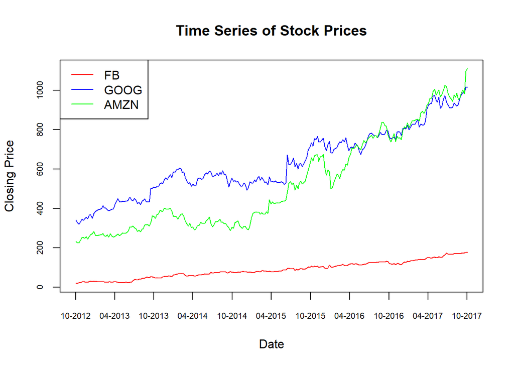

```r
FB <- weekly_long[weekly_long$company == "FB",]
GOOG <- weekly_long[weekly_long$company == "GOOG",]
AMZN <- weekly_long[weekly_long$company == "AMZN", ]
plot(as.Date(FB$date), FB$price, type="l", xaxt="n", xlab="Date",ylab="Closing Price", main="Time Series of Stock Prices",cex.axis=0.7, xlim=c(as.Date(min(weekly_long$date)), as.Date(max(weekly_long$date))),
  ylim=c(min(weekly_long$price), max(weekly_long$price)), col="red")
lines(as.Date(GOOG$date), GOOG$price, col="blue", type="l")
lines(as.Date(AMZN$date), AMZN$price, col="green", type="l")
minDate <- min(weekly_long$date)
maxDate <- max(weekly_long$date)
axis.Date(side=1, at=seq(from = as.Date(minDate), as.Date(maxDate), by="6 mon"), format="%m-%Y",cex.axis=0.7)
legend("topleft", legend = c("FB", "GOOG", "AMZN"), lty = 1, col=c("red", "blue", "green"))
```

## Problem 3: Practicing the `dplyr` package with flights data

Download `flights.csv` and `airports` from the Web to create two tibbles named `flights` and `airports`:

```r
flights<-read_csv("https://drive.google.com/uc?export=download&id=1zAE0s3FA0dvhahex5J44jT5azutDacm0", col_names = TRUE, col_types = cols())
airports<-read_csv("https://drive.google.com/uc?export=download&id=1LLthXwTC-wqXnsMPU9-nvknIAMixkmH3", col_names = TRUE, col_types = cols())
## glimpse() is a transposed version of print
glimpse(flights)
```

```
## Observations: 336,776
## Variables: 19
## $ year           <int> 2013, 2013, 2013, 2013, 2013, 2013, 2013, 2013,...
## $ month          <int> 1, 1, 1, 1, 1, 1, 1, 1, 1, 1, 1, 1, 1, 1, 1, 1,...
## $ day            <int> 1, 1, 1, 1, 1, 1, 1, 1, 1, 1, 1, 1, 1, 1, 1, 1,...
## $ dep_time       <int> 517, 533, 542, 544, 554, 554, 555, 557, 557, 55...
## $ sched_dep_time <int> 515, 529, 540, 545, 600, 558, 600, 600, 600, 60...
## $ dep_delay      <int> 2, 4, 2, -1, -6, -4, -5, -3, -3, -2, -2, -2, -2...
## $ arr_time       <int> 830, 850, 923, 1004, 812, 740, 913, 709, 838, 7...
## $ sched_arr_time <int> 819, 830, 850, 1022, 837, 728, 854, 723, 846, 7...
## $ arr_delay      <int> 11, 20, 33, -18, -25, 12, 19, -14, -8, 8, -2, -...
## $ carrier        <chr> "UA", "UA", "AA", "B6", "DL", "UA", "B6", "EV",...
## $ flight         <int> 1545, 1714, 1141, 725, 461, 1696, 507, 5708, 79...
## $ tailnum        <chr> "N14228", "N24211", "N619AA", "N804JB", "N668DN...
## $ origin         <chr> "EWR", "LGA", "JFK", "JFK", "LGA", "EWR", "EWR"...
## $ dest           <chr> "IAH", "IAH", "MIA", "BQN", "ATL", "ORD", "FLL"...
## $ air_time       <int> 227, 227, 160, 183, 116, 150, 158, 53, 140, 138...
## $ distance       <int> 1400, 1416, 1089, 1576, 762, 719, 1065, 229, 94...
## $ hour           <int> 5, 5, 5, 5, 6, 5, 6, 6, 6, 6, 6, 6, 6, 6, 6, 5,...
## $ minute         <int> 15, 29, 40, 45, 0, 58, 0, 0, 0, 0, 0, 0, 0, 0, ...
## $ time_hour      <dttm> 2013-01-01 05:00:00, 2013-01-01 05:00:00, 2013...
```

```r
summary(flights)
```

```
##       year          month             day           dep_time
##  Min.   :2013   Min.   : 1.000   Min.   : 1.00   Min.   :   1
##  1st Qu.:2013   1st Qu.: 4.000   1st Qu.: 8.00   1st Qu.: 907
##  Median :2013   Median : 7.000   Median :16.00   Median :1401
##  Mean   :2013   Mean   : 6.549   Mean   :15.71   Mean   :1349
##  3rd Qu.:2013   3rd Qu.:10.000   3rd Qu.:23.00   3rd Qu.:1744
##  Max.   :2013   Max.   :12.000   Max.   :31.00   Max.   :2400
##                                                  NA's   :8255
##  sched_dep_time   dep_delay          arr_time    sched_arr_time
##  Min.   : 106   Min.   : -43.00   Min.   :   1   Min.   :   1
##  1st Qu.: 906   1st Qu.:  -5.00   1st Qu.:1104   1st Qu.:1124
##  Median :1359   Median :  -2.00   Median :1535   Median :1556
##  Mean   :1344   Mean   :  12.64   Mean   :1502   Mean   :1536
##  3rd Qu.:1729   3rd Qu.:  11.00   3rd Qu.:1940   3rd Qu.:1945
##  Max.   :2359   Max.   :1301.00   Max.   :2400   Max.   :2359
##                 NA's   :8255      NA's   :8713
##    arr_delay          carrier              flight       tailnum
##  Min.   : -86.000   Length:336776      Min.   :   1   Length:336776
##  1st Qu.: -17.000   Class :character   1st Qu.: 553   Class :character
##  Median :  -5.000   Mode  :character   Median :1496   Mode  :character
##  Mean   :   6.895                      Mean   :1972
##  3rd Qu.:  14.000                      3rd Qu.:3465
##  Max.   :1272.000                      Max.   :8500
##  NA's   :9430
##     origin              dest              air_time        distance
##  Length:336776      Length:336776      Min.   : 20.0   Min.   :  17
##  Class :character   Class :character   1st Qu.: 82.0   1st Qu.: 502
##  Mode  :character   Mode  :character   Median :129.0   Median : 872
##                                        Mean   :150.7   Mean   :1040
##                                        3rd Qu.:192.0   3rd Qu.:1389
##                                        Max.   :695.0   Max.   :4983
##                                        NA's   :9430
##       hour           minute        time_hour
##  Min.   : 1.00   Min.   : 0.00   Min.   :2013-01-01 05:00:00
##  1st Qu.: 9.00   1st Qu.: 8.00   1st Qu.:2013-04-04 13:00:00
##  Median :13.00   Median :29.00   Median :2013-07-03 10:00:00
##  Mean   :13.18   Mean   :26.23   Mean   :2013-07-03 05:02:36
##  3rd Qu.:17.00   3rd Qu.:44.00   3rd Qu.:2013-10-01 07:00:00
##  Max.   :23.00   Max.   :59.00   Max.   :2013-12-31 23:00:00
##
```

The `flights` dataset is about all the flights that departed from New Yord City (i.e. airports JFK, LGA or EWR) in 2013. In particular, the interest lies in the following variables:

- `hour`, `minute`: the hour and minute of the departure
- `arr_delay`: the arrival delay of the incoming plane (in minutes)
- `dest`: the destination

Note that several variables have *missing values*.

##### (a) Creating new variables

Create a new variable which encodes a given `hour` and `minute` as one decimal number, i.e. time in hours; that is, for example, 2 hours 45 minutes should be coded to 2.75 hours, because 45 minutes is 45 minutes * (1 hour / 60 minutes) = 0.75 hours. Name this new variable `time` in `flights`.

```r
# edit here
flights$time <- flights$hour + flights$minute / 60.0
glimpse(flights)
```

```
## Observations: 336,776
## Variables: 20
## $ year           <int> 2013, 2013, 2013, 2013, 2013, 2013, 2013, 2013,...
## $ month          <int> 1, 1, 1, 1, 1, 1, 1, 1, 1, 1, 1, 1, 1, 1, 1, 1,...
## $ day            <int> 1, 1, 1, 1, 1, 1, 1, 1, 1, 1, 1, 1, 1, 1, 1, 1,...
## $ dep_time       <int> 517, 533, 542, 544, 554, 554, 555, 557, 557, 55...
## $ sched_dep_time <int> 515, 529, 540, 545, 600, 558, 600, 600, 600, 60...
## $ dep_delay      <int> 2, 4, 2, -1, -6, -4, -5, -3, -3, -2, -2, -2, -2...
## $ arr_time       <int> 830, 850, 923, 1004, 812, 740, 913, 709, 838, 7...
## $ sched_arr_time <int> 819, 830, 850, 1022, 837, 728, 854, 723, 846, 7...
## $ arr_delay      <int> 11, 20, 33, -18, -25, 12, 19, -14, -8, 8, -2, -...
## $ carrier        <chr> "UA", "UA", "AA", "B6", "DL", "UA", "B6", "EV",...
## $ flight         <int> 1545, 1714, 1141, 725, 461, 1696, 507, 5708, 79...
## $ tailnum        <chr> "N14228", "N24211", "N619AA", "N804JB", "N668DN...
## $ origin         <chr> "EWR", "LGA", "JFK", "JFK", "LGA", "EWR", "EWR"...
## $ dest           <chr> "IAH", "IAH", "MIA", "BQN", "ATL", "ORD", "FLL"...
## $ air_time       <int> 227, 227, 160, 183, 116, 150, 158, 53, 140, 138...
## $ distance       <int> 1400, 1416, 1089, 1576, 762, 719, 1065, 229, 94...
## $ hour           <int> 5, 5, 5, 5, 6, 5, 6, 6, 6, 6, 6, 6, 6, 6, 6, 5,...
## $ minute         <int> 15, 29, 40, 45, 0, 58, 0, 0, 0, 0, 0, 0, 0, 0, ...
## $ time_hour      <dttm> 2013-01-01 05:00:00, 2013-01-01 05:00:00, 2013...
## $ time           <dbl> 5.250000, 5.483333, 5.666667, 5.750000, 6.00000...
```

##### (b) Plotting the destinations.

Calculate the average value of the arrival delay (`arr_delay`) and the number of departing flights (`n`) for each destination (`dest`) and name the resulting data frame `delay.per.dest`.

Here you can use the summary function `n()` to find the count for each group. When calculating the mean, you should be aware of the existence of the missing values.

```r
# edit here

delay.per.dest <- summarise(group_by(flights, dest),
                   arr_delay = mean(flights$arr_delay, na.rm=TRUE),
                   n = n())
delay.per.dest
```

```
## # A tibble: 105 x 3
##    dest  arr_delay     n
##    <chr>     <dbl> <int>
##  1 ABQ        6.90   254
##  2 ACK        6.90   265
##  3 ALB        6.90   439
##  4 ANC        6.90     8
##  5 ATL        6.90 17215
##  6 AUS        6.90  2439
##  7 AVL        6.90   275
##  8 BDL        6.90   443
##  9 BGR        6.90   375
## 10 BHM        6.90   297
## # ... with 95 more rows
```

The `airports` dataset contains the coordinates (`lon`, `lat`) of the 1,458 airports. `faa` stands for FAA airport code.

```r
airports
```

```
## # A tibble: 1,458 x 8
##    faa   name                   lat    lon   alt    tz dst   tzone
##    <chr> <chr>                <dbl>  <dbl> <int> <int> <chr> <chr>
##  1 04G   Lansdowne Airport     41.1  -80.6  1044    -5 A     America/New_~
##  2 06A   Moton Field Municip~  32.5  -85.7   264    -6 A     America/Chic~
##  3 06C   Schaumburg Regional   42.0  -88.1   801    -6 A     America/Chic~
##  4 06N   Randall Airport       41.4  -74.4   523    -5 A     America/New_~
##  5 09J   Jekyll Island Airpo~  31.1  -81.4    11    -5 A     America/New_~
##  6 0A9   Elizabethton Munici~  36.4  -82.2  1593    -5 A     America/New_~
##  7 0G6   Williams County Air~  41.5  -84.5   730    -5 A     America/New_~
##  8 0G7   Finger Lakes Region~  42.9  -76.8   492    -5 A     America/New_~
##  9 0P2   Shoestring Aviation~  39.8  -76.6  1000    -5 U     America/New_~
## 10 0S9   Jefferson County In~  48.1 -123.    108    -8 A     America/Los_~
## # ... with 1,448 more rows
```

Merge the tibble `delay.per.dest` and `airports` in order to add the coordinates (`lon`, `lat`) of the airports to `delay.per.dest` using `left_join()` in `dplyr` (type `?left_join` to see how it works).

```r
# edit here
delay.per.dest <- left_join(delay.per.dest, airports, by = c("dest" = "faa"))

delay.per.dest
```

```
## # A tibble: 105 x 10
##    dest  arr_delay     n name         lat    lon   alt    tz dst   tzone
##    <chr>     <dbl> <int> <chr>      <dbl>  <dbl> <int> <int> <chr> <chr>
##  1 ABQ        6.90   254 Albuquerq~  35.0 -107.   5355    -7 A     Americ~
##  2 ACK        6.90   265 Nantucket~  41.3  -70.1    48    -5 A     Americ~
##  3 ALB        6.90   439 Albany In~  42.7  -73.8   285    -5 A     Americ~
##  4 ANC        6.90     8 Ted Steve~  61.2 -150.    152    -9 A     Americ~
##  5 ATL        6.90 17215 Hartsfiel~  33.6  -84.4  1026    -5 A     Americ~
##  6 AUS        6.90  2439 Austin Be~  30.2  -97.7   542    -6 A     Americ~
##  7 AVL        6.90   275 Asheville~  35.4  -82.5  2165    -5 A     Americ~
##  8 BDL        6.90   443 Bradley I~  41.9  -72.7   173    -5 A     Americ~
##  9 BGR        6.90   375 Bangor In~  44.8  -68.8   192    -5 A     Americ~
## 10 BHM        6.90   297 Birmingha~  33.6  -86.8   644    -6 A     Americ~
## # ... with 95 more rows
```

Create a scatterplot of the latitude against the longitude and scale the points according to the number of departing planes.

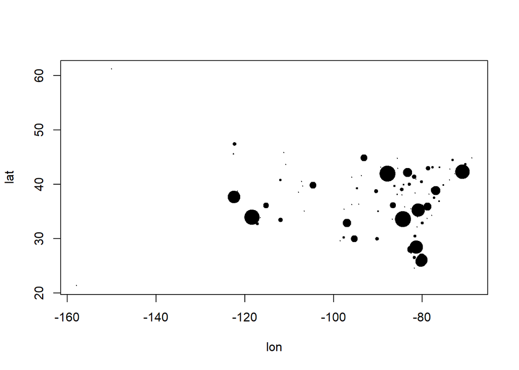

```r
plot(lat ~ lon, data = delay.per.dest, pch = 19, cex = n / 6000)
```

Explain what values are represented by the size of the bubbles. The larger the bubble, the greater the number of departing flights at that location identified by longitute & latitute.